# Tidy Tuesday 4

Kyle Bosworth

2024-12-16

### Load Libraries

```r
library(here)
library(tidyverse)
library(plotly)
library(dplyr)
library(ggbiplot) # specific package for PCA visualization
```

### Read in Data from TidyTuesday GitHub

```r
episode_metrics <- readr::read_csv('https://raw.githubusercontent.com/rfordatascience/tidytuesday/main/data/2024/2024-11-19/episode_metrics.csv')
```

Goal: Create a PCA Plot I have wanted to learn how to create a PCA plot for this tidy tuesday I will be using the Bobs Burgers Data set. I thought that this would be a cool dataset to try this out on because of the type of values (numerical) are in each category of this data set.

### Prepare the data

```r
# Filter data so that we only include the seasons 1-3 first, using all seasons because too much too look at all at once
episode_metrics_filtered <- episode_metrics %>%
  filter(season %in% c(1, 2, 3))

# select the variables for PCA
pcadata <- episode_metrics_filtered %>%
  select(dialogue_density, unique_words, exclamation_ratio) %>%
  na.omit() %>%
  scale() # scale() standardizes the variable to have a mean = 0 and sd = 1, important for PCA
```

### Preform PCA

```r
# using the scaled data, preform PCA using prcomp
PCAresults <- prcomp(pcadata, scale. = TRUE)

# calculate the proportion of variance explained by each individal Principal Component (PC)
var_explained <- PCAresults$sdev^2 / sum(PCAresults$sdev^2) * 100
```

### Creating the PCA biplot using ggbiplot

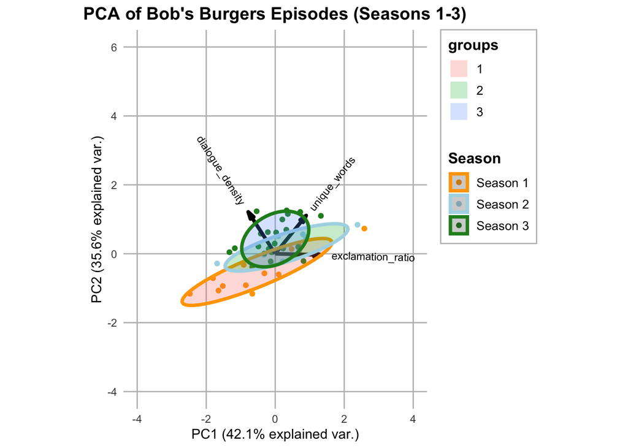

```r
PCAplot <- ggbiplot(PCAresults,
                    obs.scale = 1, #scales
                    var.scale = 1,
                    groups = factor(episode_metrics_filtered$season), #colorby filtered seasons
                    ellipse = TRUE, # this adds confidence eclipses
                    circle = FALSE) + #removed confidence circles to simplify the plot
  xlim(-4, 4) +  # these dictate the x-axis limits
  ylim(-4, 6) +  # y-axis limits
  scale_color_manual(name = "Season",
                    values = c("orange", "lightblue", "forestgreen"),
                    labels = c("Season 1", "Season 2", "Season 3")) +
  theme_minimal() +
  theme(
    legend.position = "right",
    legend.justification = c(1, 1),
    legend.box.background = element_rect(color = "gray", fill = "white", size = 0.5),
    legend.margin = margin(6, 6, 6, 6),
    panel.grid.major = element_line(color = "gray"),
    panel.grid.minor = element_blank(),
    plot.title = element_text(size = 14, hjust = 0.5, face = "bold"),
    legend.title = element_text(size = 12, face = "bold"),
    legend.text = element_text(size = 10)
  ) +
  labs(
    title = "PCA of Bob's Burgers Episodes (Seasons 1-3)",
    x = sprintf("PC1 (%.1f%% explained var.)", var_explained[1]), #adds titles to inform variance trends
    y = sprintf("PC2 (%.1f%% explained var.)", var_explained[2])
  )
print(PCAplot)
```

PC1 - 42.1% of the variance - represent the direction of maximum variation in this simplified data set (Seasons 1-3). It shows the strongest pattern in how dialog density, unique words, and exclamation ratio vary together across episodes/seasons.

PC2 - 35.6% of the variance - represents the second most significant pattern of variation, uncorrelated to PC1.